# Geog533 Lab 9

Complete the following exercises in Chapter 9 (More on Regression) of the textbook pages 286-287.

## Question 1

This is Exercise 7 in Chapter 9 of the Textbook [R].

The following results were obtained from a regression of $n = 14$ housing prices (in dollars) on median family income, size of house, and size of lot:

|  | Sum of squares | df | Mean square | F |
| --- | --- | --- | --- | --- |
| Regression SS: | 4234 | 3 |  |  |
| Residual SS: | 3487 |  |  |  |
| Total SS: |  |  |  |  |

|  | Coefficient (b) | Standard error (sb) | VIF |
| --- | --- | --- | --- |
| Median family income | 1.57 | 0.34 | 1.3 |
| Size of house (sq.ft) | 23.4 | 11.2 | 2.9 |
| Size of lot (sq.ft) | -9.5 | 7.1 | 11.3 |
| Constant | 40,000 | 1000 |  |

### Question 1(a)

Fill in the blanks.

```r
library(knitr)
col1 <- c("Regression SS:","Residual SS:","Total SS:")
col2 <- c("4234","3487","7721")
col3 <- c("3","10","13")
col4 <- c("1411.333","348.7","593.923")
col5 <- c("4.0474","","")
df <- cbind(col1,col2,col3,col4,col5)
colnames(df) <- c("","Sum of squares"," df ","Mean square "," F")
kable(df)
```

|  | Sum of squares | df | Mean square | F |
| --- | --- | --- | --- | --- |
| Regression SS: | 4234 | 3 | 1411.333 | 4.0474 |
| Residual SS: | 3487 | 10 | 348.7 |  |
| Total SS: | 7721 | 13 | 593.923 |  |

### Question 1(b)

What is the value of $r^2$?

```r
r2 <- 4234/7721
r2
```

```
[1] 0.5483746
```

### Question 1(c)

What is the standard error of the estimate?

```r
se <- sqrt(348.7)
se
```

```
[1] 18.67351
```

### Question 1(d)

Test the null hypothesis that $R^2 = 0$ by comparing the $F-statistic$ from the table with its critical value.

```r
F <- 4.0474
f <- qf(0.95,3,10)
f
```

```
[1] 3.708265
```

```r
if(F<f){
  print("we accept null hypothesis that r2 = 0")
}else{
  print("we reject null hypothesis that r2 = 0")
}
```

```
[1] "we reject null hypothesis that r2 = 0"
```

### Question 1(e)

Are the coefficients in the direction you would hypothesize? If not, which coefficients are opposite in sign from what you would expect?

```r
print("the size of lot is not in the direction I would hypothesize")
```

```
[1] "the size of lot is not in the direction I would hypothesize"
```

### Question 1(f)

```r
t1 <- 1.57/0.34
t2 <- 23.4/11.2
t3 <- -9.5/7.1
t.critical1 <- qt(0.975, df = 13)
t.critical2 <- qt(0.025, df = 13)
if(t1 > t.critical1){
  print("we reject the null hypotheses that coefficients median family income are equal to zero")
}else{
  print("we accept the null hypotheses that coefficients median family income are equal to zero")
}
```

```
[1] "we reject the null hypotheses that coefficients median family income are equal to zero"
```

```r
if(t2 > t.critical1){
  print("we reject the null hypotheses that coefficients size of house are equal to zero")
}else{
  print("we accept the null hypotheses that coefficients size of house are equal to zero")
}
```

```
[1] "we accept the null hypotheses that coefficients size of house are equal to zero"
```

```r
if(t3 < t.critical2){
  print("we reject the null hypotheses that coefficients size of lot are equal to zero")
}else{
  print("we accept the null hypotheses that coefficients size of lot are equal to zero")
}
```

```
[1] "we accept the null hypotheses that coefficients size of lot are equal to zero"
```

### Question 1(g)

What do you conclude from the variance inflation factors (VIFs)? What (if any) modifications would you recommend in light of the VIFs?

```r
vif.lot <- 11.3
if(vif.lot > 5){
  print("the value has the potential multicollinearity problem, we need to remove this value")
}
```

```
[1] "the value has the potential multicollinearity problem, we need to remove this value"
```

### Question 1(h)

What is the predicted sales price of a house that is 1500 square feet, on a lot 60´×100´, and in a neighborhood where the median family income is $40,000?

```r
sales <- 1.57*40000 + 23.4*1500 + 40000
sales
```

```
[1] 137900
```

## Question 2

This is Exercise 10 in Chapter 9 of the Textbook [R].

### Question 2(a)

Using R and the [Hypothetical UK Housing Prices dataset](http://spatial.binghamton.edu/geog533/data/UK_Housing.csv), construct a regression equation using housing price as the dependent variable, and bedrooms, bathrooms, date built, garage, fireplace, floor area, and whether the home is detached as the independent variables. Investigate the importance of multicollinearity and outliers. Comment on the weaknesses of this specification, and on the results.

```r
url = "http://spatial.binghamton.edu/geog533/data/UK_Housing.csv"
df <- read.csv(file = "http://spatial.binghamton.edu/geog533/data/UK_Housing.csv", header = T)
y <- df$price
x1 <- df$bedrooms
x2 <- df$bathrooms
x3 <- df$datebuilt
x4 <- df$garage
x5 <- df$fireplace
x6 <- df$floorarea
x7 <- df$detached
m <- lm(y ~ x1 + x2 + x3 + x4 + x5 + x6 + x7, data = df)
m
```

```
Call:
lm(formula = y ~ x1 + x2 + x3 + x4 + x5 + x6 + x7, data = df)

Coefficients:
(Intercept)           x1           x2           x3           x4           x5           x6           x7
  -256087.2        686.0       2637.3        130.4      10980.8      -3144.4        374.2      13186.8
```

```r
summary(m)
```

```
Call:
lm(formula = y ~ x1 + x2 + x3 + x4 + x5 + x6 + x7, data = df)

Residuals:
   Min     1Q Median     3Q    Max
-38150  -6933  -1086   6705  64014

Coefficients:
              Estimate Std. Error t value Pr(>|t|)
(Intercept) -256087.18   34854.98  -7.347 8.50e-13 ***
x1              686.01     742.27   0.924   0.3558
x2             2637.29    1526.36   1.728   0.0846 .
x3              130.36      17.84   7.306 1.12e-12 ***
x4            10980.77    1274.94   8.613  < 2e-16 ***
x5            -3144.39    1227.89  -2.561   0.0107 *
x6              374.18      22.22  16.842  < 2e-16 ***
x7            13186.76    2346.12   5.621 3.19e-08 ***
---
Signif. codes:  0 *** 0.001 ** 0.01 * 0.05 . 0.1   1

Residual standard error: 11550 on 491 degrees of freedom
Multiple R-squared:  0.6967,    Adjusted R-squared:  0.6924
F-statistic: 161.1 on 7 and 491 DF,  p-value: < 2.2e-16
```

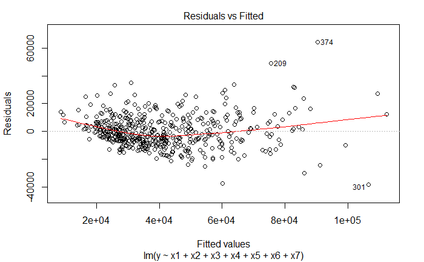

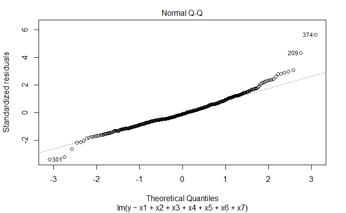

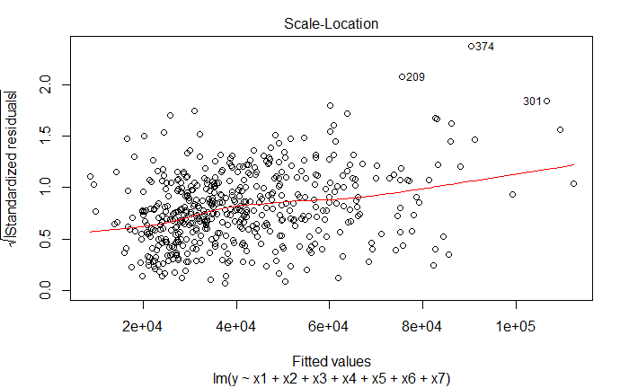

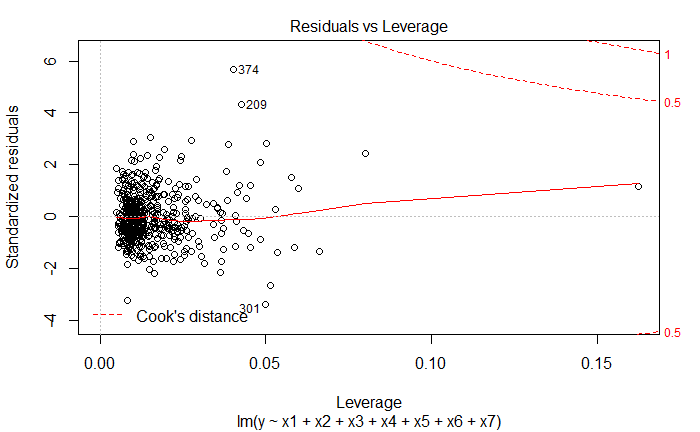

```r
plot(m)
```

```r
result <- anova(m)
r2_gargage <- (result$`Sum Sq`[1])/(sum(result$`Sum Sq`))
VIF_gargage <- 1/(1-r2_gargage)
r2_bedrooms <-(result$`Sum Sq`[2])/(sum(result$`Sum Sq`))
VIF_bedrooms <- 1/(1-r2_bedrooms)
r2_bathrooms <-(result$`Sum Sq`[3])/(sum(result$`Sum Sq`))
VIF_bathrooms <- 1/(1-r2_bathrooms)
r2_datebuilt <-(result$`Sum Sq`[4])/(sum(result$`Sum Sq`))
VIF_datebuilt <- 1/(1-r2_datebuilt)
r2_floorarea <-(result$`Sum Sq`[5])/(sum(result$`Sum Sq`))
VIF_floorarea <- 1/(1-r2_floorarea)
r2_detached <-(result$`Sum Sq`[6])/(sum(result$`Sum Sq`))
VIF_detached <- 1/(1-r2_detached)
r2_fireplace<-(result$`Sum Sq`[7])/(sum(result$`Sum Sq`))
VIF_fireplacee <- 1/(1-r2_fireplace)
c2 <- rbind(VIF_gargage,VIF_bedrooms,VIF_bathrooms,VIF_datebuilt,VIF_floorarea,VIF_detached,VIF_fireplacee)
c1 <- rbind("1","2","3","4","5","6","7")
Vif <- cbind(c1,c2)
colnames(Vif) <- c("Number","VIF")
library(knitr)
kable(Vif)
```

|  | Number | VIF |
| --- | --- | --- |
| VIF_gargage | 1 | 1.37042787807683 |
| VIF_bedrooms | 2 | 1.01049748518285 |
| VIF_bathrooms | 3 | 1.05883928421159 |
| VIF_datebuilt | 4 | 1.16626463789032 |
| VIF_floorarea | 5 | 1.00099624118978 |
| VIF_detached | 6 | 1.24588160976315 |
| VIF_fireplacee | 7 | 1.01990411938219 |

### Question 2(b)

Attempt to improve the regression equation found in (a). Justify your decisions in constructing and carrying out the analysis.

```r
full.model <- lm(y ~  x1 + x2 + x3 + x4 + x5 + x6 + x7, data = df)
reduced.model <- step(full.model, direction="backward")
```

```
Start:  AIC=9343.39
y ~ x1 + x2 + x3 + x4 + x5 + x6 + x7

       Df  Sum of Sq        RSS    AIC
- x1    1 1.1388e+08 6.5578e+10 9342.3
<none>               6.5464e+10 9343.4
- x2    1 3.9804e+08 6.5862e+10 9344.4
- x5    1 8.7433e+08 6.6339e+10 9348.0
- x7    1 4.2121e+09 6.9676e+10 9372.5
- x3    1 7.1168e+09 7.2581e+10 9392.9
- x4    1 9.8904e+09 7.5355e+10 9411.6
- x6    1 3.7819e+10 1.0328e+11 9568.9

Step:  AIC=9342.26
y ~ x2 + x3 + x4 + x5 + x6 + x7

       Df  Sum of Sq        RSS    AIC
<none>               6.5578e+10 9342.3
- x2    1 3.8265e+08 6.5961e+10 9343.2
- x5    1 8.6500e+08 6.6443e+10 9346.8
- x7    1 4.3063e+09 6.9884e+10 9372.0
- x3    1 7.7124e+09 7.3290e+10 9395.7
- x4    1 1.0025e+10 7.5603e+10 9411.2
- x6    1 6.0089e+10 1.2567e+11 9664.8
```

```r
m2 <- lm(y ~ x2 + x3 + x4 + x5 + x6 + x7, data = df)
m2
```

```
Call:
lm(formula = y ~ x2 + x3 + x4 + x5 + x6 + x7, data = df)

Coefficients:
(Intercept)           x2           x3           x4           x5           x6           x7
  -261362.0       2584.0        133.4      11040.8      -3127.2        386.0      13311.3
```

```r
anova(m2)
```

```
Analysis of Variance Table

Response: y
           Df     Sum Sq    Mean Sq  F value    Pr(>F)
x2          1 3.0128e+09 3.0128e+09  22.6035 2.619e-06 ***
x3          1 1.9641e+10 1.9641e+10 147.3572 < 2.2e-16 ***
x4          1 5.2348e+10 5.2348e+10 392.7397 < 2.2e-16 ***
x5          1 2.0321e+05 2.0321e+05   0.0015    0.9689
x6          1 7.0944e+10 7.0944e+10 532.2604 < 2.2e-16 ***
x7          1 4.3063e+09 4.3063e+09  32.3078 2.257e-08 ***
Residuals 492 6.5578e+10 1.3329e+08
---
Signif. codes:  0 *** 0.001 ** 0.01 * 0.05 . 0.1   1
```

```r
print("housing price = -261362 + bathrooms*2584 + datebuilt*133.4 + garge*11040.8 + fireplace*(-3127.2) + floorarea*386 + detached*13311.2")
```

```
[1] "housing price = -261362 + bathrooms*2584 + datebuilt*133.4 + garge*11040.8 + fireplace*(-3127.2) + floorarea*386 + detached*13311.2"
```